# Parent-Specific Gene Expression Analysis (PSGEA) workflow

Sean T. Bresnahan and David A. Galbraith

Department of Entomology, Center for Pollinator Research, Huck Institutes of the Life Sciences, Pennsylvania State University  
Molecular, Cellular, and Integrative Biosciences Graduate Program, Huck Institutes of the Life Sciences, Pennsylvania State University

stb5321@psu.edu

11 February 2021

```r
# NOTE: Remember to replace this with your project directory
wd <- "/Volumes/Sean/PSGEA_pipeline"
# Set the working directory to wd
setwd(wd)
# Set the code chunk options for knitr | in engine.opts we set bash = "-l" so that R Studio points to the native bash profile
library(knitr)
knitr::opts_chunk$set(warning=FALSE, message=FALSE, eval=F,
                      engine.opts = list(bash = "-l"))
```

```r
# Load packages
library(ggplot2)
library(tidyr)
library(plyr)
library(viridis)
library(kableExtra)
library(Biostrings)
library(stringr)
library(ape)
library(tximport)
library(GenomicFeatures)
library(plyranges)
library(DESeq2)
library(cowplot)
library(gplots)
library(topGO)
library(factoextra)
library(data.table)
library(grid)
```

# 1 Summary

This workflow describes methods for detecting allele-biased expression differences, or Parent-Specific Gene Expression (PSGE) from NGS data (adapted from methods described in (Galbraith et al., 2016)). Briefly, the sequences of the genomes of parents are analyzed to identify SNPs to distinguish between paternal and maternal alleles in offspring. DNA sequencing reads are processed and assessed for quality control metrics using [Trim Galore](https://www.bioinformatics.babraham.ac.uk/projects/trim_galore/) - a wrapper tool around [Cutadapt](https://cutadapt.readthedocs.io/en/stable/) and [FastQC](https://www.bioinformatics.babraham.ac.uk/projects/fastqc/). The trimmed DNA sequencing reads are then aligned to a reference genome; in this case, the latest *Apis mellifera* [Amel_HAv3.1 genome assembly](https://ftp.ncbi.nih.gov/genomes/refseq/invertebrate/Apis_mellifera/annotation_releases/104/GCF_003254395.2_Amel_HAv3.1/) using [Bowtie2](http://bowtie-bio.sourceforge.net/bowtie2/index.shtml) `--local`. The sequence alignment files (SAM) generated by Bowtie2 are then converted to BAM format using [Samtools](http://www.htslib.org), which are then used to generate a list of SNPs for each parent, using [Freebayes](https://github.com/ekg/freebayes), which can be adjusted to account for ploidy in each individual. Heterozygous SNPs from diploid individuals are then removed using [bedtools](https://bedtools.readthedocs.io/en/latest/), leaving only homozygous SNPs in both parents. The remaining SNPs are then used to create an alternate reference for each parent by replacing the reference base at the SNP site with the variant detected with Freebayes, using the FastaAlternateReferenceMaker tool, available through the [Genome Analysis Tool Kit](https://gatk.broadinstitute.org/hc/en-us) (GATK). These alternate references represent the genomes of each parent, on which the RNA-seq reads of respective offspring are aligned (using Bowtie2, allowing for 0 mismatches), and testing for allele-biased expression differences in R (using [DESeq2](https://bioconductor.org/packages/release/bioc/html/DESeq2.html)).

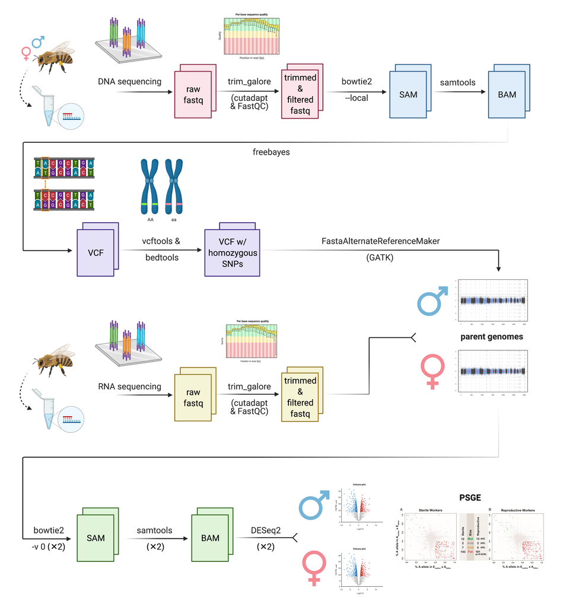

Parent Specific Gene Expression Analysis (PSGEA) pipeline

# 2 Machine setup

```bash
# Configure R Studio for running bash commands
# ---------- #

# In order to "run" everything within R, we use Rmarkdown's bash code chunk functionality. This is equivalent to calling system2() on the entire chunk. Problematically, R Studio creates a new/temporary bash environment for each call to system2()...rather than re-declare each necessary variable for each bash chunk (in the name of keeping everything "in R") we create a file "rvars_PSGEA" which stores all the necessary variables (including the working directory, which you'll need to edit here if running from scratch) which we call at the beginning of each bash chunk. To ensure such a file does not already exist, we begin by deleting any files names "rvars_PSGEA" in the home directory (NOTE: don't name any important files in the home directory "rvars_PSGEA" unless you want to cry!)
rm rvars_PSGEA

# NOTE: Remember to replace this with your project directory
# Create rvars_PSGEA
echo 'export PROJECT_DIR=/Volumes/Sean/PSGEA_pipeline' > rvars_PSGEA
echo 'conda activate bioinformatics' >> rvars_PSGEA
echo 'export OUT_DIR=data/mod' >> rvars_PSGEA
echo 'export SRA_LIST=index/files.txt' >> rvars_PSGEA

# Here is how we will point system2() to rvars_PSGEA at the beginning of each bash chunk
source rvars_PSGEA
cd ${PROJECT_DIR}
# ---------- #
```

# 3 Experimental design

```r
# In order to work with our data, we need to load a "metadata" table into R that describes our samples. A "metadata.csv" file already exists in the repository, but you could re-create it from the original SRA project metadata file
metadata <- read.csv("index/metadata_DNA.csv",header=T)
```

# 4 Process parent DNA

First, the NGS data are fetched from the [Short Read Archive](https://www.ncbi.nlm.nih.gov/sra), using the `prefetch` and `fasterq-dump` commands from the NCBI [SRA Toolkit](https://anaconda.org/bioconda/sra-tools).

## 4.1 Fetch data

```bash
# ---------- #
source rvars_PSGEA
cd ${PROJECT_DIR}
# ---------- #

# Declare a variable pointing to the directory we want prefetch to download to
ncbi_dir="${PROJECT_DIR}/data/raw"
# Tell sra-tools to set this as the default download directory
echo "/repository/user/main/public/root = \"$ncbi_dir\"" > $HOME/.ncbi/user-settings.mkfg
# Create an empty list
SRA=()
# Open index/metadata_DNA.csv and save the accession values in column 1 to a txt file
cat index/metadata_DNA.csv | tail -n+2 | awk -F"," '{print $1}' | uniq > index/DNA_SRA_accessions.txt
# For each line in SRA_accessions.txt, read the line into a new element in SRA
while IFS= read -r line; do
    SRA+=("$line")
done < index/DNA_SRA_accessions.txt

# Call prefetch to download these accessions
prefetch ${SRA[*]}

# For each accession in SRA, call fasterq-dump to generate the paired-end fastq files
cd data/raw/sra
for i in "${SRA[@]}"; do
  fasterq-dump $i
done

# For each fastq file in the directory, compress with pigz
for filename in *.fastq; do
  pigz --best "$filename"
done

# Reset sra-tools default download directory
echo "~/ncbi/public/sra = \"$ncbi_dir\"" > $HOME/.ncbi/user-settings.mkfg
```

## 4.2 Trim reads

NGS reads are then assessed for quality control metrics after adapter trimming with Trim Galore.

```r
# Add a column to metadata containing our paired-end fastq file names
metadata$fastq.file.name <- paste(metadata$accession,
                            rep.int(list("1.fastq.gz","2.fastq.gz"),
                                    length(metadata$accession)/2),sep="_")
# Like before, we need to create a txt file to point the following bash commands to these files
file.list <- data.frame(file.name=paste(wd,"data/raw/sra",
                                        metadata$fastq.file.name,sep="/"))
write.table(file.list,"index/temp.txt",quote=F,col.names=F,row.names=F)
```

```bash
# NOTE: eval=F | downstream files already exist in repository | if running from scratch, set eval=T (or just run in bash like a normal person)
source rvars_PSGEA
cd ${PROJECT_DIR}
# ---------- #

# Declare a list
FILE_LIST=()
# Read each line of temp.txt into this list
while IFS= read -r line; do
    FILE_LIST+=("$line")
done < index/temp.txt

# Call trim_galore | here we have set -j (# of processor core threads to delegate to this command) to 4... you may want to change this depending on your system specs!
trim_galore --fastqc -j 4 --paired ${FILE_LIST[*]} -o ${OUT_DIR}

# Delete temp.txt
rm index/temp.txt
```

## 4.3 Align reads on reference genome

### 4.3.1 Download genome

We obtain the RefSeq *Apis mellifera* [Amel_HAv3.1 genome assembly](https://ftp.ncbi.nih.gov/genomes/refseq/invertebrate/Apis_mellifera/annotation_releases/104/GCF_003254395.2_Amel_HAv3.1/) and the NCBI Annotation Report v104 (AR104) GFF file from NCBI.

```r
# NOTE: eval=F | files already exist in repository | if running from scratch, set eval=T

# Download the Amel_HAv3.1 genome (fasta) file
genome.url <- "https://ftp.ncbi.nlm.nih.gov/genomes/all/GCF/003/254/395/GCF_003254395.2_Amel_HAv3.1/GCF_003254395.2_Amel_HAv3.1_genomic.fna.gz"
download.file(genome.url,"index/GCF_003254395.2_Amel_HAv3.1_genomic.fna.gz")

# Download the Amel_HAv3.1 genome annotation (gff) file
gff.url <- "https://ftp.ncbi.nlm.nih.gov/genomes/all/GCF/003/254/395/GCF_003254395.2_Amel_HAv3.1/GCF_003254395.2_Amel_HAv3.1_genomic.gff.gz"
download.file(gff.url,"index/GCF_003254395.2_Amel_HAv3.1_genomic.gff.gz")
```

```bash
# NOTE: eval=F | downstream files already exist in repository | if running from scratch, set eval=T (or just run in bash like a normal person)
echo "export GFF_FILE=index/GCF_003254395.2_Amel_HAv3.1_genomic.gff.gz" >> rvars_PSGEA
echo "export GFF_FILE_O=index/GCF_003254395.2_Amel_HAv3.1_genomic.gff" >> rvars_PSGEA
echo "export GENOME_FILE=index/GCF_003254395.2_Amel_HAv3.1_genomic.fna.gz" >> rvars_PSGEA
echo "export GENOME_FILE_O=index/GCF_003254395.2_Amel_HAv3.1_genomic.fna" >> rvars_PSGEA
```

```r
# Set the gff file path
file.gff <- "index/GCF_003254395.2_Amel_HAv3.1_genomic.gff"
```

### 4.3.2 Build Bowtie2 index

Then, we build an alignment index for Bowtie2 using the genome fasta file downloaded above.

```bash
# Build bowtie2 index
# NOTE: eval=F | downstream files already exist in repository | if running from scratch, set eval=T (or just run in bash like a normal person)
# ---------- #
source rvars_PSGEA
cd ${PROJECT_DIR}
cd index
# ---------- #

# Call gunzip to unzip the downloaded files
gunzip ${GFF_FILE}
gunzip ${GENOME_FILE}

# Call bowtie2-build to compile the reference genome
bowtie2-build GCF_003254395.2_Amel_HAv3.1_genomic.fna Amel_Hav3.1
```

### 4.3.3 Align

Trimmed NGS reads are then aligned to the reference genome

```r
# Add a column to metadata containing our pre-processed paired-end fastq file names
metadata$trimmed.file.name <- paste(metadata$accession,
                            rep.int(list("1_val_1.fq","2_val_2.fq"),
                                    length(metadata$accession)/2),sep="_")
# Like before, we need to create a txt file to point the following bash commands to these files
file.list <- data.frame(file.name=paste(wd,"data/mod",
                                        metadata$trimmed.file.name,sep="/"))
write.table(file.list,"index/temp.txt",quote=F,col.names=F,row.names=F)
```

```bash
# NOTE: eval=F | downstream files already exist in repository | if running from scratch, set eval=T (or just run in bash like a normal person)
# ---------- #
source rvars_PSGEA
cd ${PROJECT_DIR}
# ---------- #

# Declare a list
FILE_LIST2=()
# Read each line of temp.txt into this list
while IFS= read -r line; do
    FILE_LIST2+=("$line")
done < index/temp.txt

# Because we're working with paired-end fastq files, but we want to automate the process with a list, we will need to get a little fancy here. Instead of looping over each file, we only want to run our loop for each pair... so, we declare FILE_NUM as the number of fastq files / 2...
FILE_NUM=($(expr ${#FILE_LIST2[@]} / 2))

# ...and set our "counter" to 0, adding +2 at the end of each loop.
i=0
for run in $(seq 1 $FILE_NUM); do
  # Set the output directory to a new directory called kallisto_*accession*
  OUT_DIR=($(echo ${FILE_LIST2[${i}]} | sed 's:.*/::' | sed 's/_.*//'))
  OUT_FILENAME="data/res/bowtie2/"$OUT_DIR"/".sam
  # Call bowtie2 on each pair
  bowtie2 -p 4 -q --local -x ${PROJECT_DIR}/index/Amel_HAv3.1 -1 ${FILE_LIST2[${i}]} -2 ${FILE_LIST2[${i}+1]} > ${OUT_FILENAME}
  let i+=2
done

# Delete temp.txt
rm ./index/temp.txt
```

### 4.3.4 Filter and sort SAM; convert to BAM

```bash
# NOTE: eval=F | downstream files already exist in repository | if running from scratch, set eval=T (or just run in bash like a normal person)
# ---------- #
source rvars_PSGEA
cd ${PROJECT_DIR}
cd data/res/bowtie
# ---------- #

for filename in *.sam; do
  samtools view -F 4 -O BAM "$filename" | samtools sort -O BAM > bam/"$filename".bam
done
```

## 4.4 Call SNPs on reference genome

```r
# Add a column to metadata containing our pre-processed paired-end fastq file names
metadata$bam <- paste(metadata$accession,
                            rep.int(".sam.bam",length(metadata$accession)),sep="")
```

### 4.4.1 Diploid (queen) samples

```r
metadata.sub <- metadata[metadata$parent=="Queen"&metadata$pair==1,]
# Like before, we need to create a txt file to point the following bash commands to these files
file.list <- data.frame(file.name=paste(wd,"data/res/bowtie",
                                        metadata.sub$bam,sep="/"))
write.table(file.list,"index/queens.txt",quote=F,col.names=F,row.names=F)
```

```bash
# NOTE: eval=F | downstream files already exist in repository | if running from scratch, set eval=T (or just run in bash like a normal person)
# ---------- #
source rvars_PSGEA
cd ${PROJECT_DIR}
# ---------- #

# Declare a list
FILE_LIST=()
# Read each line of temp.txt into this list
while IFS= read -r line; do
    FILE_LIST+=("$line")
done < index/queens.txt

for i in "${FILE_LIST[@]}"; do
  freebayes -f $GENOME_FILE_O $i > data/res/freebayes/$i.vcf
done

rm index/queens.txt
```

### 4.4.2 Haploid (drone) samples

```r
metadata.sub <- metadata[metadata$parent=="Drone"&metadata$pair==1,]
# Like before, we need to create a txt file to point the following bash commands to these files
file.list <- data.frame(file.name=paste(wd,"data/res/bowtie",
                                        metadata.sub$bam,sep="/"))
write.table(file.list,"index/drones.txt",quote=F,col.names=F,row.names=F)
```

```bash
# NOTE: eval=F | downstream files already exist in repository | if running from scratch, set eval=T (or just run in bash like a normal person)
# ---------- #
source rvars_PSGEA
cd ${PROJECT_DIR}
# ---------- #

# Declare a list
FILE_LIST=()
# Read each line of temp.txt into this list
while IFS= read -r line; do
    FILE_LIST+=("$line")
done < index/drones.txt

for i in "${FILE_LIST[@]}"; do
  freebayes -p 1 -f $GENOME_FILE_O $i > data/res/freebayes/$i.vcf
done

rm index/drones.txt
```

## 4.5 Remove heterozygous SNPs from queens

## 4.6 Remove SNPs shared between parents

## 4.7 Filter SNPs not shared by all crosses

## 4.8 Generate alternative reference genomes for each parent

# 5 Process offspring RNA

## 5.1 Setup

## 5.2 Fetch data

## 5.3 Trim reads

## 5.4 Align reads

# 6 Assess PSGE

## 6.1 Compute %mat / %pat expression in offspring

## 6.2 Test for allelic expression differences in offspring

# References

Galbraith, D., Kocher, S., Glenn, T., Albert, I., Hunt, G., Strassmann, J., Queller, D., & Grozinger, C. (2016). Testing the kinship theory of intragenomic conflict in honey bees. *PNAS*, *113*(4), 1020–1025.